**Lab #10 Markdown File**

# Can Music Tell If You’re Unwell? Exploring the Relationship Between Popular Music Sentiments and Societal Mental Wellbeing

## Introduction

The intersection of music and mental health has long been a fascination to researchers and the public. The impact of music on people can be significant, as it is a profound reflection of the collective emotional and cultural currents of its time. It can have the power to convey complex emotions and dispositions and perhaps provide a therapeutic outlet.  
Historically, music and art have played a significant role in human society, serving not only as a form of entertainment but also as a means of communication, a method of healing, and a catalyst for emotional expression and social change. For example, slave songs in the US represented both deep sorrow and a yearning for freedom, providing both a psychological outlet and a means of resistance and communication (Levine, 1977).  
Understanding this relationship has important implications for public health policies, music therapy, and cultural studies. Depression rates have increased to unprecedented highs especially with the burden of COVID-19 (Goodwin et al., 2022), making deeper analysis and more information regarding this topic to be ever critical. The possibility of music being able to analyze and evaluate mental health conditions is an avenue that must be explored. As famed musician and band leader David Byrne has stated, “Music tells us things – social things, psychological things, physical things about how we feel and perceive our bodies – in a way that other art forms can’t” (Byrne, 2012). By examining popular music on platforms like Spotify, this research focus aims to understand how contemporary society uses music as a reverse outlet for expressing or coping with collective emotions.

## Background

Previous research has explored various aspects of the relationship between music and mental health. For example, studies have shown that music listening can significantly affect mood and can even be used as an intervention in clinical depression (Yinger & Gooding, 2014). Other research has shown that engaging with music and art can reduce stress, alleviate anxiety, improve mood, and even enhance cognitive function (Leubner & Hinterberger, 2017; Stuckey & Nobel, 2010). However, these established benefits are all concluded from experiments in clinical settings. In other words, these benefits derive out of structured, music therapy sessions, not personal listening. There remains a substantial gap in literature specifically addressing the predictive relationship between the emotional content of widely consumed, unrestricted, popular music and broader mental health trends.  
While studies have found that adolescents’ music dependency increases during periods of depression (McFerran et al., 2014), the broader implications of these results for the general population and the overall impact of music preferences on mental health remains unclear. Another recent factor that must be considered is the rise of digital media, which has transformed access to music and art, as vast libraries of songs, artworks, and performances are available and easily accessible to users. Platforms like Spotify, YouTube, and various art-sharing websites not only provide access but also allow better insights and research into consumer preferences and trends through built-in data analytics. Preliminary studies suggest that music and art consumption trends may connect to character trait distributions, with changes in genre popularity correlating to economic, social, and political changes (Rentfrow et al., 2011; Liu et al., 2018). In regards to Spotify specifically, studies have been able to find correlations between listening behavior and music and users’ personality traits (Anderson et al., 2020).  
However, there exists a notable lack of research linking the emotional content of songs with longitudinal mental health outcomes in the general population. Such studies, done over extended periods of time to capture general mental health trends, could potentially reveal predictive relationships that could be used for early identification of mental health trends, enabling better-targeted interventions and policies. As online platform usage for music and art engagement continuously rises, patterns in these activities could serve as early indicators of mental health shifts across different demographics.  
The increase in mental health issues globally, as indicated by the World Health Organization, further underscores the need for innovative research approaches that incorporate music, as both a diagnostic tool and a therapeutic medium. Mental disorders have skyrocketed in recent years, with more and more people in mental health facilities now (Insel, 2023). This project could significantly contribute to public health strategies by providing data-driven insights into mental health indicators. Reseach in this realm could lead to original, creative approaches in mental health awareness and intervention programs. Additionally, this research may open new academic pathways for studying the impacts of other cultural factors on mental health, establishing opportunities for similar studies across different media and contexts. The potential to strengthen mental health interventions and foster a deeper understanding of cultural dynamics makes this research not only relevant but essential to the ongoing effort to fight the mental health crisis.

### Definitions and Hypotheses

For my experiment, I decided to select sadness sentiment and depression sentiment of songs as the two independent variables, as they are significant terms within mental health discourse and depression especially has seen an unprecedented rise in recent decades (Hidaka, 2012). To maintain accuracy and preciseness of the research, I used the definition for depression from the National Institute of Mental Health and the definition of sadness from Paul Eckman’s, an esteemed leader in emotions and psychology.  
“Depression (also known as major depression, major depressive disorder, or clinical depression) is a common but serious mood disorder. It causes severe symptoms that affect how a person feels, thinks, and handles daily activities, such as sleeping, eating, or working” (NIMH, n.d.) “Sadness describes the range, or family, of emotional states we can experience containing everything from mild disappointment to extreme despair and anguish. Some sad states, starting from least intense to most intense are disappointment, discouragement, distraught, resignation, helplessness, misery, despair, grief, sorrow, and anguish” (Paul Ekman Group, 2022)  
In creating my hypotheses, I wanted to analyze the relationships these variables had on mental health levels in the US as well as whether one was more significant than the other in determining mental health levels. Based on previous research, I predicted that sadder/more depressed songs would be correlated with lower mental wellbeing; in other words, the sentiment of popular songs would directly reflect mental health states. Based on the definitions and the fact that “sadness is considered… a core symptom of depression” (Mouchet-Mages & Baylé, 2008), I believed that the correlation difference between songs’ sadness levels and mental health levels and songs’ depression levels and mental health levels would be insignificant because the two concepts are so closely intertwined.

- **Hypothesis 1:** There is a statistically significant relationship between sadness scores of most popular songs and overall health scores, where increases in sadness scores are associated with decreases in overall mental health scores.
- **Hypothesis 2:** There is a statistically significant relationship between depression sentiment level of most popular songs and overall health scores, where increases in depression scores are associated with decreases in overall mental health scores.
- **Hypothesis 3:** The correlation between the sadness levels in top songs and overall mental health is not significantly different from the correlation between depression sentiment levels in top songs and overall mental health.

## Results

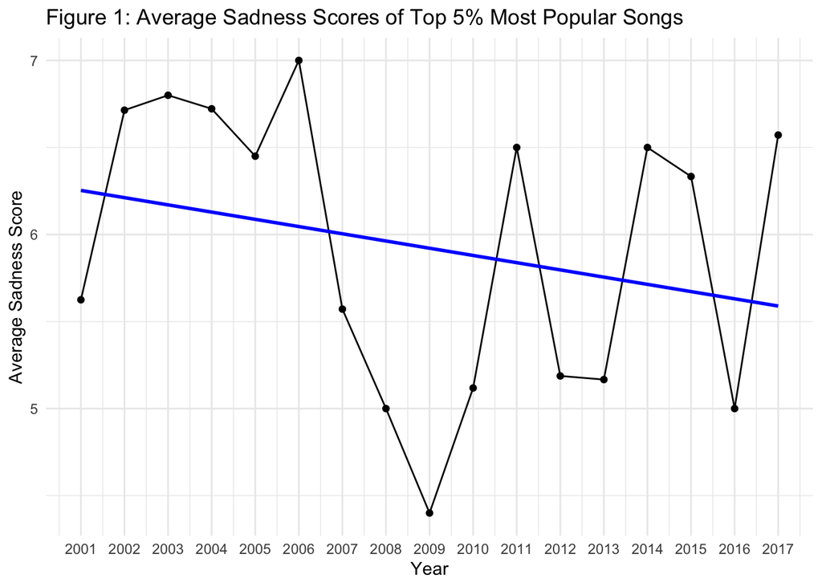

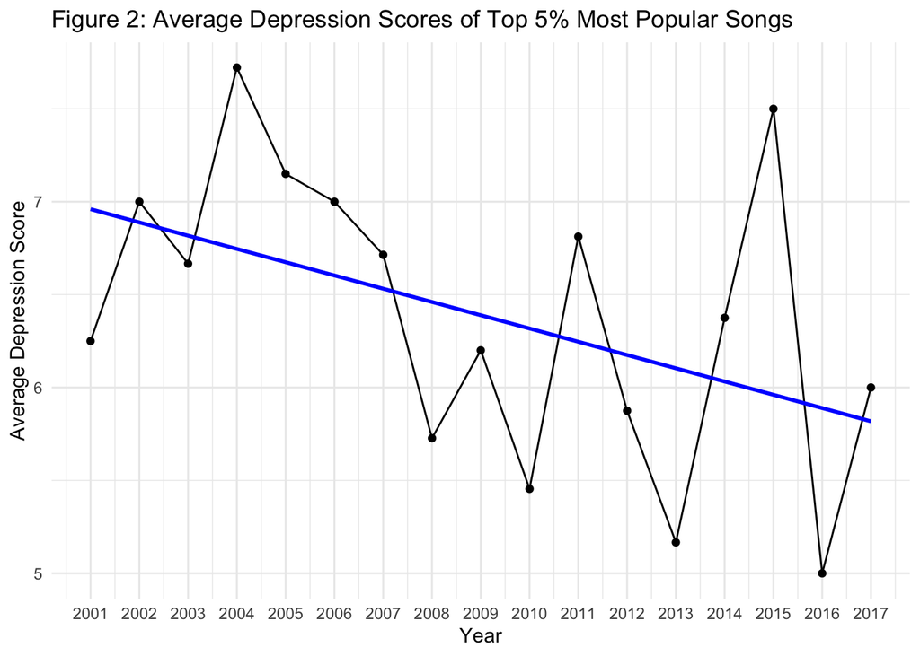

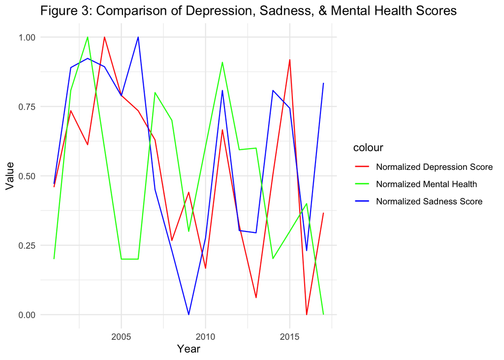

From Figure 1 and 2, we can see the general trend of the resulting averaged sadness and depression levels, respectively, based on year. Both levels have decreased over time; however, the slope for depression is a little steeper than the line for sadness, meaning the depression levels for songs have decreased at a faster rate than for sadness level. Since the depression and sadness scores range from 1 to 10 and the mental health scores range from 1 to 4, Figure 3 shows a standardized version of all the scores so that they range from 0 to 1 for easier comparison. Based on the hypothesis, whenever we see positive slopes for sadness and depression, we should see a negative slope for mental health for that same time period (as sadness and depression increases, mental health decreases). We should also be able to see the reverse. It can sort of be seen in 2004-2006, but then there is a roughly overall downward slope for all factors in 2007-2009 and then upward slope for all 3 from 2009-2011. More analysis is necessary as it is unclear if the hypothesis is correct or not due to the inability to extract a consistent pattern from Figure 3.

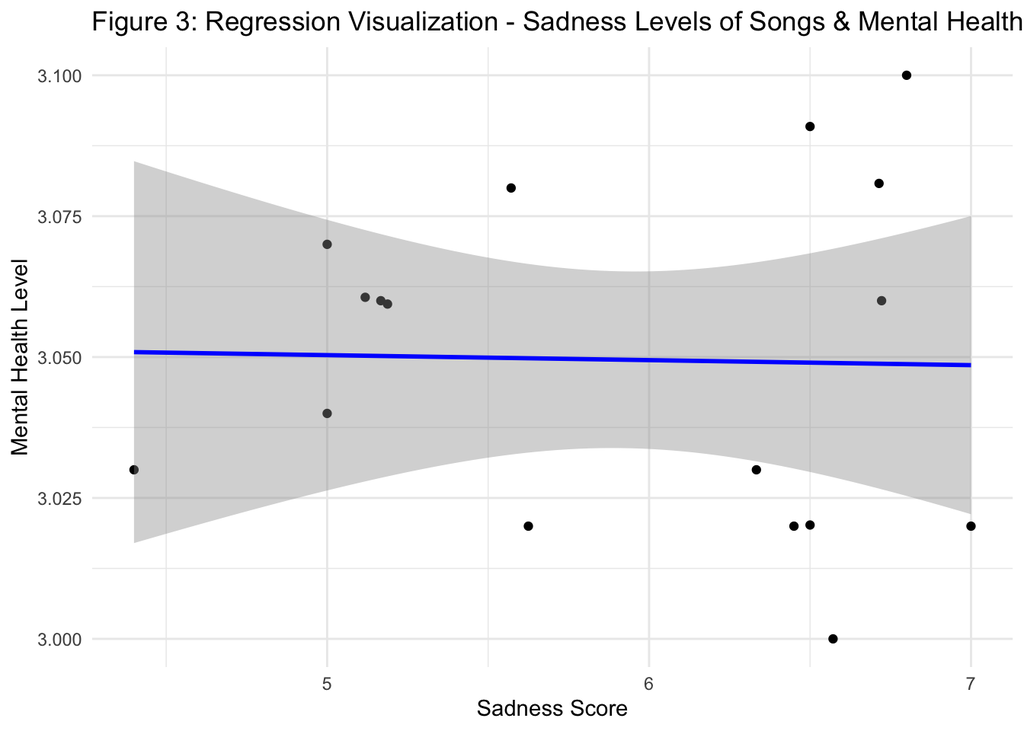

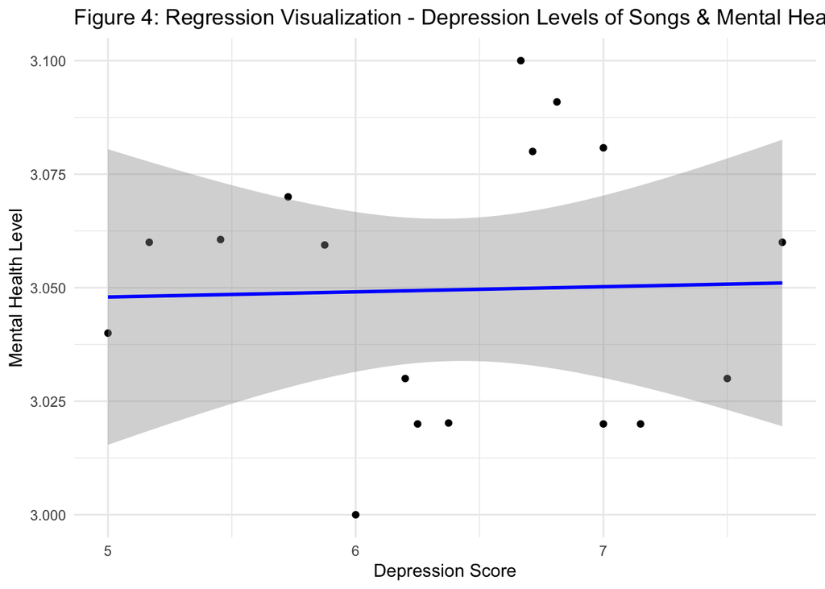

Figures 3 and 4 are linear model representations that demonstrate the relationships between mental health and sadness scores of top songs and mental health and depression scores of top songs, respectively. From first glance, it seems as though no strong correlation exists between mental health levels and either of the independent variables as the dots are still quite scattered and not very close to the predicted line. Further breakdown of the regression model must be conducted.

Figure 5: Regression Data for Sadness Level and Depression Level Variables

```
       Model Estimate P_Value T_Value R_Squared
1    Sadness   -0.001   0.925  -0.096   0.00061
2 Depression    0.001   0.908   0.118   0.00092
```

Figure 6: Correlation Table for Variables’ Relationships

```
                   Variables Correlation
1    Sadness & Mental Health      -0.025
2 Depression & Mental Health       0.030
3       Sadness & Depression       0.723
```

The correlation coefficient for sadness sentiment of top songs and overall mental health is approximately -0.025, suggesting that there is an inverse relationship where top songs’ sadness levels increase while overall health scores decrease (and vice versa), which is in line with the hypothesis’s prediction. However, the correlation coefficient is close to 0, meaning the strength of the correlation between the sadness levels of songs and mental health scores is very weak. The p-value is 0.925, meaning the relationship between the 2 are not statistically significant since the p-value is greater than 0.05. The data shows there is no statistically significant relationship between most popular songs’ sadness scores and mental health levels; hypothesis 1 cannot be proven true.  
The correlation coefficient for depression sentiment of top songs and overall mental health is approximately 0.03, indicating that as songs’ depression levels increase, overall mental health scores also increase (proportional relationship). This is not in the same direction of Hypothesis 2. This correlation coefficient is also is very close to 0, meaning the correlation strength between the two variables is extremely weak. Additionally, the p-value for is 0.908, implying that the relationship between the 2 are not statistically significant. Thus, there is no statistically significant relationship between most popular songs’ depression scores and mental health levels; hypothesis 2 cannot be proven true.  
Only about 0.06% of the variability in mental health ratings is explained by sadness score changes and about 0.09% of mental health variability can be explained by depression score changes, meaning the two models are quite weak and not suitable for predicting mental health. The very low R-squared values of both models show that sadness and depression scores of popular songs are not good predictors for mental health levels; instead, there are other factors out there that better influence mental health levels and predict its variability.

Figure 7: Correlation Comparison between Sadness Levels of Songs and Mental Health vs. Depression Levels of Songs and Mental Health

```
  Z_Score P_Value
1  -0.306    0.76
```

## LIMITATIONS

This experiment has several key limitations that affect the accuracy, robustness, and generalizability of the results:

1. **Sample Size and Data Selection**: The sample size of only 142 songs may be too small to effectively detect if a relationship exists and also makes it unable to generalize any patterns to a broader population or context. The small sample size was because I could only filter out the top 5% most popular songs in each year to use due to extensive processing times by OpenAI, the system I used to analyze song lyric sentiment. This selective filtering could lead to inaccuracies as it does not best represent all the popular songs within each year. In the future, a larger, more representative sample might produce more accurate results and allow for better detection of underlying relationships.
2. **Data Timeframe and Relevance**: The data utilized has time limitations. The Gallup data begins in 2001 and the Spotify data concludes in 2017, forcing the time period analyzed to be strictly 2001 to 2017. Extending the timeframe of the study to include more recent data, especially from 2019-2020 which encompasses the onset of COVID-19 (another intriguing factor to test in future studies), could provide valuable insights. As mental health becomes a more acknowledged topic, newer data sources are likely to be more comprehensively sourced and measured, enhancing the study’s relevance and utility. The research can also be extended into the past as well, but the data for mental health for earlier years is difficult to find and not continuous as well. It would be ideal to use data from certified expert mental health organizations such as the NIH, but their data has gaps in certain years.
3. **Data Source Limitations**:
   - **Gallup Poll Data**: The mental health data from Gallup is self-reported, which may compromise the credibility of the responses since individuals are not mental health experts. Additionally, being a survey, it is subject to non-response bias, with responses likely skewing towards those with strong opinions on the topic, potentially making the results unrepresentative and ungeneralizable to the entire US population.
   - **Spotify User Demographics**: The results apply only to Spotify users, which does not represent entire U.S. population of music listeners. Spotify’s demographic tends to skew younger and more tech-savvy, meaning older groups may not be well-represented. I chose Spotify because it is the leading platform for music (Steele & Journal, 2024) but there are other music platforms like Apple Music and Pandora, which also have significant user bases, that were not included in the study, making the study not applicable to all music listeners in the US. Future research could perhaps analyze all possible streaming platforms, or at least a larger amount of platforms so the results are more representative of the entire population.
4. **Technology and Analysis Limitations**:
   - **Machine Accuracy**: The use of OpenAI for evaluating depression and sadness levels in song lyrics may introduce inaccuracies. Artificial intelligence, while advanced, is still prone to mistakes and requires precise training and model specifications to yield beneficial results (Burtsev et al., 2023). This aspect emphasizes the need for cautious interpretation of the findings derived from AI analyses. Due to the relatively new uprise of AI, the results must be faced with a dose of healthy suspicion. I used ChatGPT 3.5 for this experiment, but a new version, ChatGPT 4, has already been released and has been modified to be more accurate than previous versions. Utilizing GPT 4 or other developed artificial models may generate different, more significant results.
   - **Prompt Structure**: Future studies may find a benefit in restructuring or rewording the prompt to generate different results. I tried to be as precise and descriptive as possible in the prompt, but it is still possible there is some error in the way I am asking OpenAI to complete the task of assigning sentiment scores.
5. **Statistical Methods**: Based on the results, a linear regression does not seem to be the most suitable for this study. Instead, future experiments could try the other regression models available, such as polynomial or logistic, to test for better fit.
6. **Scope of Factors Considered**: The study focused solely on 2 factors: depression and sadness levels in song lyrics. Future research should expand to include other potential influences and variables on mental health, such as general demographics (race, socioeconomic status, etc.), environmental factors, and major events, to better understand the complexities of mental health dynamics. The insignificant findings strongly imply that there are other confounding factors not considered that have a much more significant impact on mental health levels in the US.

These limitations highlight the need for methodological refinements, expansive and accurate data collection, and more comprehensive analytical frameworks in future studies to improve the validity and applicability of the findings.

## BIBLIOGRAPHY

Aalbers, S., Fusar-Poli, L., Freeman, R., Spreen, M., Ket, H., Vink, A. C., Maratos, A., Crawford, M., Chen, X. J., & Gold, C. (2017). Music therapy for depression. Cochrane Library, 2017(11). https://doi.org/10.1002/14651858.cd004517.pub3  
Anderson, I., Gil, S., Gibson, C., Wolf, S. T., Shapiro, W., Semerci, O., & Greenberg, D. M. (2020). “Just The Way You Are”: linking music listening on Spotify and personality. Social Psychological & Personality Science, 12(4), 561–572. https://doi.org/10.1177/1948550620923228  
Brenan, B. M. (2024, February 28). Americans’ mental health ratings sink to new low. Gallup.com. https://news.gallup.com/poll/327311/americans-mental-health-ratings-sink-new-low.aspx  
Burtsev, M., Reeves, M., & Job, A. (2023, November). The working limitations of large language models. MIT Sloan Management Review. Retrieved April 27, 2024, from https://sloanreview.mit.edu/article/the-working-limitations-of-large-language-models/  
Byrne, D. (2012). How music works. http://ci.nii.ac.jp/ncid/BB11221374  
Depression. (n.d.). National Institute of Mental Health (NIMH). https://www.nimh.nih.gov/health/topics/depression  
Graham, Y., & Baldwin, T. (2014). Testing for Significance of Increased Correlation with Human Judgment. Proceedings of the 2014 Conference on Empirical Methods in Natural Language Processing, 172–176. https://doi.org/10.3115/v1/d14-1020  
Hidaka, B. H. (2012). Depression as a disease of modernity: Explanations for increasing prevalence. Journal of Affective Disorders, 140(3), 205–214. https://doi.org/10.1016/j.jad.2011.12.036  
Levine, L. W. (1993). Slave Songs and Slave Consciousness: Explorations in Neglected sources. In Oxford University Press eBooks (pp. 35–58). https://doi.org/10.1093/acprof:oso/9780195082975.003.0003  
Leubner, D., & Hinterberger, T. (2017). Reviewing the effectiveness of music interventions in treating Depression. Frontiers in Psychology, 8. https://doi.org/10.3389/fpsyg.2017.01109  
Liu, M., Hu, X., & Schedl, M. (2018). The relation of culture, socio-economics, and friendship to music preferences: A large-scale, cross-country study. PloS one, 13(12), e0208186. https://doi.org/10.1371/journal.pone.0208186  
Mouchet-Mages, S., & Baylé, F. (2008). Sadness as an integral part of depression. Dialogues in Clinical Neuroscience, 10(3), 321–327. https://doi.org/10.31887/dcns.2008.10.3/smmages  
Rentfrow, P. J., Goldberg, L. R., & Levitin, D. J. (2011). The structure of musical preferences: a five-factor model. Journal of personality and social psychology, 100(6), 1139–1157. https://doi.org/10.1037/a0022406  
Steele, A., & Journal, P. C. F. W. S. (2024, January 18). Spotify dominates audio streaming, but where are the profits? WSJ. https://www.wsj.com/business/media/spotify-streaming-music-podcasts-audiobooks-3e88180d  
Stuckey, H. L., & Nobel, J. (2010). The connection between art, healing, and public health: A review of current literature. American Journal of Public Health, 100(2), 254–263. https://doi.org/10.2105/AJPH.2008.156497  
Yinger, O. S., & Gooding, L. (2014). Music therapy and music medicine for children and adolescents. Child and adolescent psychiatric clinics of North America, 23(3), 535–553. https://doi.org/10.1016/j.chc.2013.03.003  
What is Sadness? | Feeling Sadness | Paul Ekman Group. (2022, November 4). Paul Ekman Group. https://www.paulekman.com/universal-emotions/what-is-sadness/  
Zhao. (n.d.). spotify-song-lyric-analysis/readme.html at master · zhao1701/spotify-song-lyric-analysis. GitHub. https://github.com/zhao1701/spotify-song-lyric-analysis/blob/master/readme.html